# Magpies in the ALA

Maps

Animalia

Chordata

Aves

Magpies are the single most recorded species in the ALA, with over 1.4 million records available. Here we use this iconic species to demonstrate how to do hex mapping in R using our new R package, ‘galah’.

Matilda Stevenson  
2021-04-14

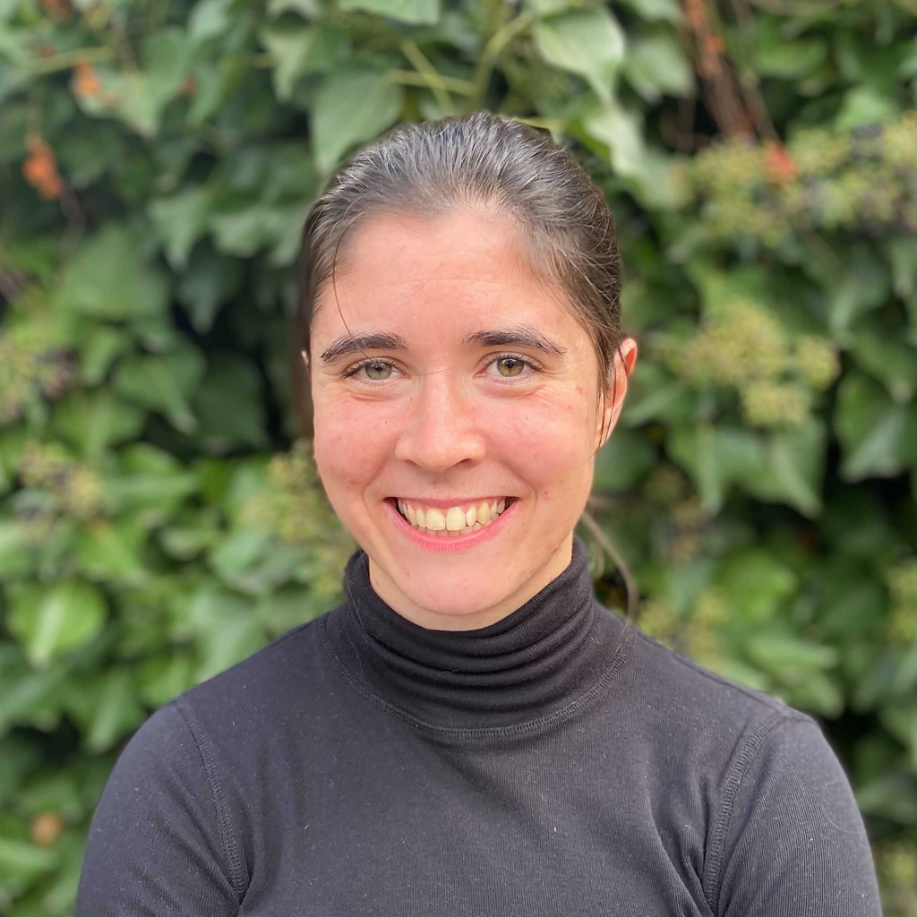

#### Author:

Matilda Stevenson

#### Date:

14 April, 2021

# Download records

First we load the required packages

```r
# packages
library(ggplot2)
library(tidyr)
library(ozmaps)
library(sf)
# library(hexbin) # You should be prompted to download when creating map
```

We will use the [galah](https://atlasoflivingaustralia.github.io/galah/index.html) package to download records. (If running this code yourself, you also need to set an email associated with your data download request, substituting your email with `myemail@email.com`)

```r
library(galah)
galah_config(email = "myemail@email.com")
```

Now we can download magpie occurrence records by using `ala_occurrences()`. Note that we also set our data ‘profile’ to ‘ALA’; this means we only download records that meet some basic data quality standards enfored by the atlas. This is optional, but tends to improve the quality of the data returned.

```r
# Download magpie occurrence records using `galah`
magpie_occ <- ala_occurrences(
  taxa = select_taxa("Cracticus tibicen"),
  filters = select_filters(profile = "ALA")
)
```

For the purpose of this exercise, we’re going to filter records not on the mainland or Tasmania.

```r
filtered_occ <- magpie_occ %>% dplyr::filter(decimalLongitude < 155,
                                      decimalLongitude > 110,
                                      decimalLatitude > -45,
                                      decimalLatitude < -10)
```

# Create map

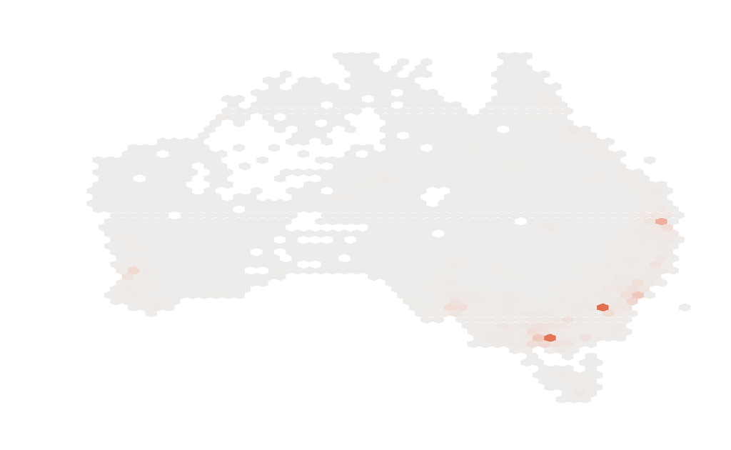

```r
# Hexagon map using geom_hex
ggplot(filtered_occ) +
  geom_hex(mapping = aes(x = decimalLongitude, y = decimalLatitude), bins = 55) +
  ylim(-45, -10) +
  xlim(110, 155) +
  scale_fill_gradientn(colours = c("#EEECEA", "#E06E53")) +
  theme_bw() +
  theme(
    panel.border = element_blank(),
    panel.grid.major = element_blank(),
    panel.grid.minor = element_blank(),
    axis.text = element_blank(),
    axis.ticks = element_blank(),
    axis.title = element_blank(),
    legend.position = "none")
```

While automated methods exist (e.g. `hexbin`), we can build a hexagon map by manually creating hexagons, linking them to a grid of Australia and adding our data of magpie counts to set the `fill` color of those hexagons. To achieve this, we first convert the map of Australia provided by `ozmaps` to the same coordinate system as ALA data

```r
# Convert map of aus to same coordinate system as ALA points
aus <- st_transform(ozmaps::ozmap_country, 4326)
```

We then transform points from our data frame of magpie occurrences to the correct coordinates

```r
# transform points
points <- lapply(1:nrow(filtered_occ), function(x) {
  st_point(c(filtered_occ[x,'decimalLongitude'],
             filtered_occ[x,'decimalLatitude']))
})
```

Now build the hexagonal grid

```r
# Build hexagonal grid
grid_all <- st_make_grid(aus, cellsize = 1, what = "polygons", square = FALSE)[aus]
gridSF <- st_as_sf(grid_all)

# Find which polygon each point is in
intersect <- st_intersects(st_as_sfc(points) %>% st_set_crs(4326), gridSF)

# count the number of points in each hexagon
freqs <- as.data.frame(table(unlist(intersect)), stringsAsFactors = FALSE)

names(freqs) <- c("hex_id", "count")
```

Add our magpie counts data to the hexagons and fill hexagons without data

```r
# Add counts to hexagons
freqs$hex_id <- as.integer(freqs$hex_id)

# fill in the values for hexagons with no records
filled_freqs <- freqs %>%
  complete(hex_id = full_seq(c(1,925), 1), fill = list(count = 0))
gridSF$n <- filled_freqs$count
```

Finally, build the plot

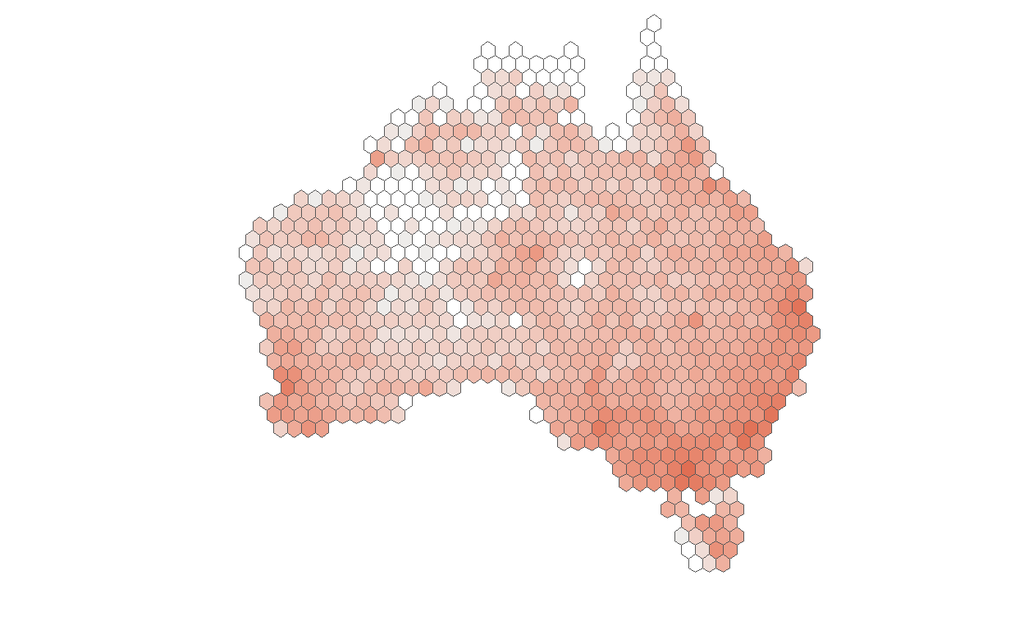

```r
# Plot the hexagons in ALA colours, with log-transformed counts
ggplot() +
  geom_sf(data = gridSF, aes(fill = n), size = .01) +
  scale_fill_gradientn(colours = c("#EEECEA", "#E06E53"), na.value = "white", trans = "log2") +
  ylim(-45, -10) +
  xlim(110, 155) +
  theme_bw() +
  theme(
    panel.border = element_blank(),
    panel.grid.major = element_blank(),
    panel.grid.minor = element_blank(),
    axis.text = element_blank(),
    axis.ticks = element_blank(),
    axis.title = element_blank(),
    legend.position = "none")
```

See the [original R script](https://github.com/AtlasOfLivingAustralia/science/blob/main/comms/2021-04_magpies/magpie_occ_vis.R)